# Final Project: Visualizations

Thomas Bahng

March 9, 2020

- This file creates some visualizations to support modeling and presentation.

# Plot Trends in Listings and Price Over Time

- Annual listing data for New York City was collected from [insideairbnb](http://insideairbnb.com/get-the-data.html) on March 9, 2020.
- Each of the five files are exclusive listings datasets from 2015 - 2019

### Read Yearly Listing Summary Data

- December (year-end) listings data collected for each year from 2015-2019.

```r
# read yearly listing summary data
fnames = list.files('data', pattern = 'listings_201\\d12.csv', full.names = TRUE)
df_list = lapply(
  fnames,
  function(x) fread(x)
)
# name each data set
names(df_list) <- 2015:2019
# dimensions of each data set
sapply(df_list, dim)
```

```
##       2015  2016  2017  2018  2019
## [1,] 34376 40227 47691 49056 50599
## [2,]    16    16    16    16    16
```

### Plot: Growth in Listings Over Time

```r
df <- map_df(df_list, ~as.data.frame(.x), .id="year")
dfplot <- df %>% count(year, neighbourhood_group)
head(dfplot) %>% kable(., row.names = FALSE)
```

| year | neighbourhood_group | n |
| --- | --- | --- |
| 2015 | Bronx | 416 |
| 2015 | Brooklyn | 13286 |
| 2015 | Manhattan | 17860 |
| 2015 | Queens | 2628 |
| 2015 | Staten Island | 186 |
| 2016 | Bronx | 628 |

```r
nycGrowth <- data.frame(
  year = 2016:2019,
  perc_growth = round(diff(tapply(dfplot$n, dfplot$year, sum)) / tapply(dfplot$n, dfplot$year, sum)[1:4],2)
)
```

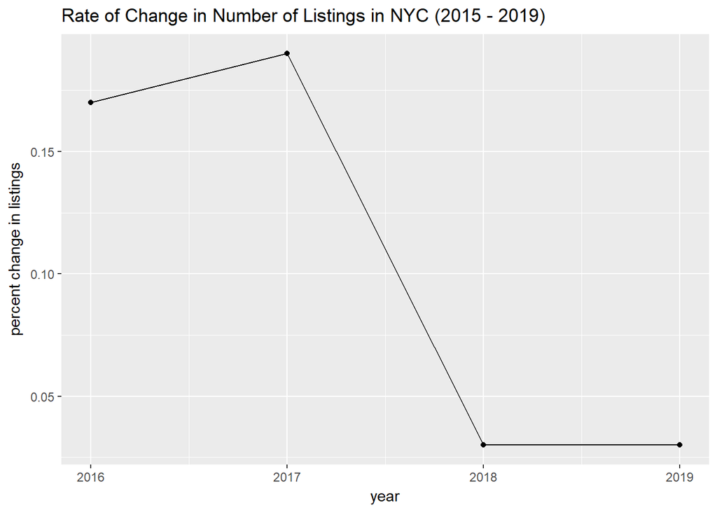

```r
ggplot(nycGrowth, aes( x = year, y = perc_growth )) +
  geom_point() + geom_line() +
  ylab("percent change in listings") +
  ggtitle("Rate of Change in Number of Listings in NYC (2015 - 2019)")
```

*The growth rate in AirBnb listings in NYC has significantly decreased from 2015 - 2019.*

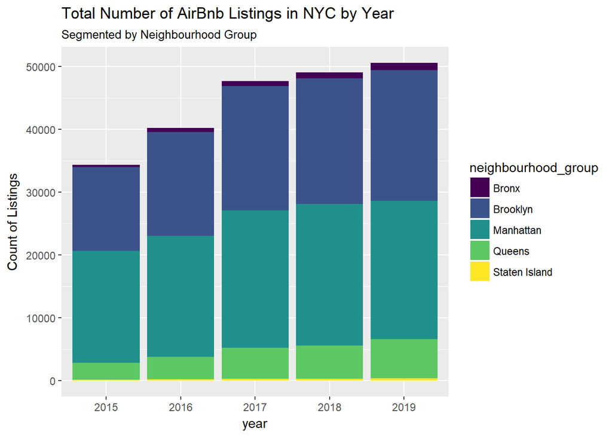

```r
ggplot(dfplot, aes(x = year, y = n, fill = neighbourhood_group)) +
  geom_col() +
  scale_fill_viridis(discrete = TRUE) +
  ylab("Count of Listings") +
  ggtitle("Total Number of AirBnb Listings in NYC by Year",
          subtitle = "Segmented by Neighbourhood Group")
```

*Overall trend shows an increase in listings, with the majority share of listings in Brooklyn and Manhattan.*

```r
# listings growth rate by neighbourhood
ngroups <- c('Bronx','Brooklyn','Manhattan','Queens','Staten Island')
# function to get YoY growth rate given neighbourhood group
getGrowth <- function(x) {
  d <- dfplot[dfplot$neighbourhood_group == x,]
  arr <- tapply(d$n, d$year, sum)
  out <- round(diff(arr)/arr[1:length(arr)-1], 2)
  return(out)
}
# dataframe of YoY change
dYearDelta <- as.data.frame(sapply(ngroups, getGrowth) %>% t)
dYearDelta$neighbour_group <- ngroups
dYearDelta <- dYearDelta[,c('neighbour_group','2016','2017','2018','2019')]
dYearDelta %>%
  kable(., caption = "Year-over-Year Rate of Change in Listings by Neighbourhood Group",
        row.names = FALSE)
```

Year-over-Year Rate of Change in Listings by Neighbourhood Group

| neighbour_group | 2016 | 2017 | 2018 | 2019 |
| --- | --- | --- | --- | --- |
| Bronx | 0.51 | 0.33 | 0.11 | 0.31 |
| Brooklyn | 0.25 | 0.19 | 0.01 | 0.04 |
| Manhattan | 0.08 | 0.14 | 0.03 | -0.02 |
| Queens | 0.36 | 0.37 | 0.08 | 0.17 |
| Staten Island | 0.19 | 0.36 | 0.06 | 0.18 |

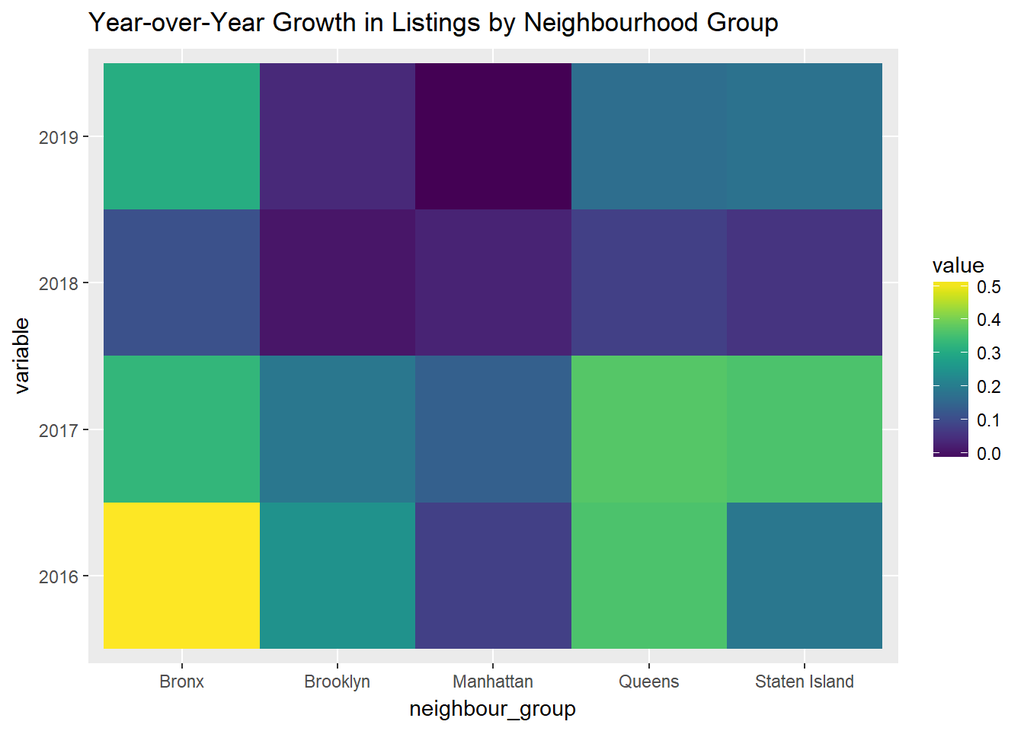

```r
ggplot(melt(dYearDelta), aes(x = neighbour_group, y = variable, fill = value)) +
  geom_tile() +
  scale_fill_viridis() +
  ggtitle("Year-over-Year Growth in Listings by Neighbourhood Group")
```

*Average annual growth across all NYC neighbourhood groups was 0.1875. The neighbourhoods with the strongest growth year-over-year were Bronx, Queens, and Staten Island.*

### Plot: Distribution of Log Listing Price Over Time

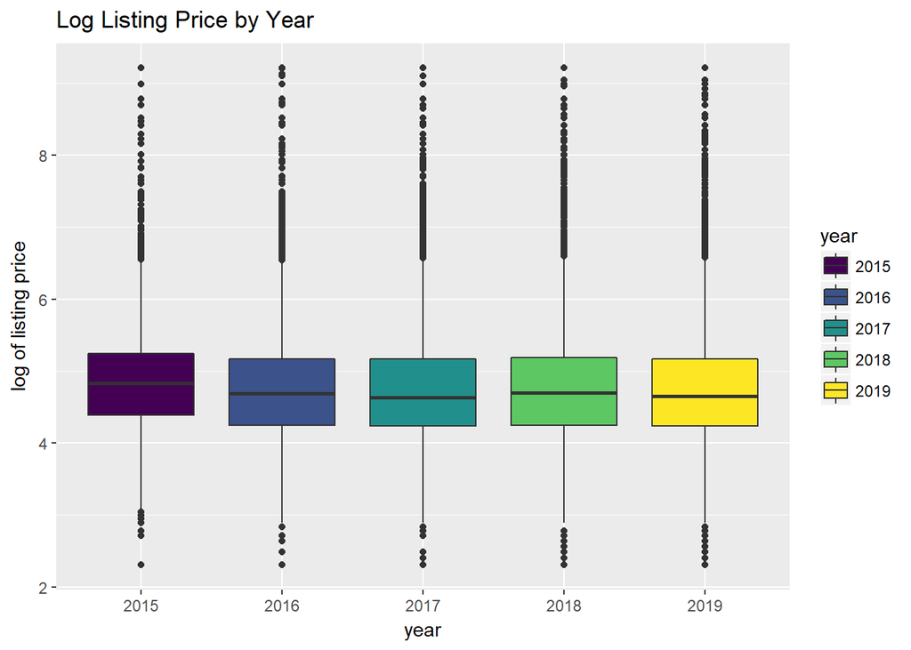

```r
dfplot2 <- df[,c('year', 'price')]
dfplot2$year <- as.factor(dfplot2$year)
# log transform price
dfplot2$logprice <- log(dfplot2$price)
ggplot(dfplot2, aes(y = logprice, factor(year), fill = year)) +
  geom_boxplot() +
  scale_fill_viridis(discrete = TRUE) +
  xlab('year') +
  ylab('log of listing price') +
  ggtitle("Log Listing Price by Year")
```

*Prices haven’t changed too much year-over-year. The average listing price across all listings stayed relatively stable around 152.18.*

### Plot: Distribution of Listing Price Over Time by Neighbourhood Group

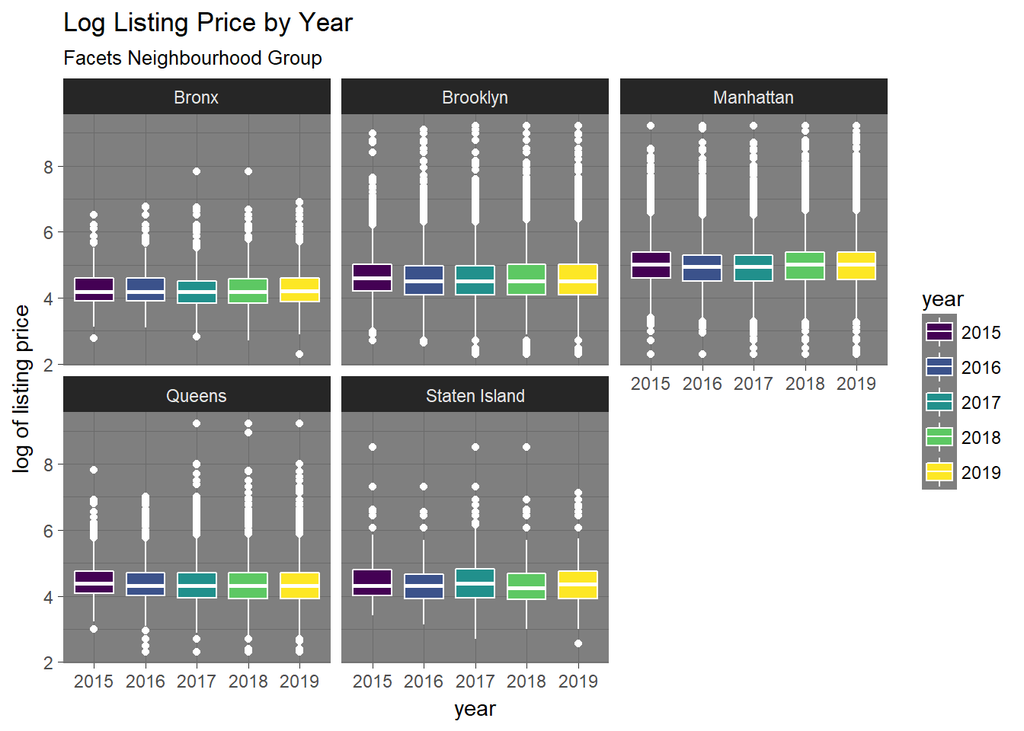

```r
dfplot3 <- df[,c('year', 'neighbourhood_group', 'price')]
dfplot3$year <- as.factor(dfplot3$year)
# log transform price
dfplot3$logprice <- log(dfplot3$price)
ggplot(dfplot3, aes(y = logprice, factor(year), fill = year)) +
  geom_boxplot(color = 'white') +
  scale_fill_viridis(discrete = TRUE) +
  xlab('year') +
  theme_dark() +
  ylab('log of listing price') +
  facet_wrap(~neighbourhood_group) +
  ggtitle("Log Listing Price by Year",
          subtitle = "Facets Neighbourhood Group")
```

*Again, prices appeared to have remained stable over the years even by neighbourhood group.*

# Visualization of Key Variables for Modeling

```r
# cleaned listings data for 2019, including census attributes
df <- fread('data/listings_cleaned.csv')
```

### Plot: How Does Review Data Affect Price?

```r
keep_cols <- c(names(df)[grepl(pattern = 'review', names(df))], 'price')
dfplot <- as.data.frame(df) %>% .[, keep_cols] %>%
  .[, sapply(., is.numeric)] %>% .[complete.cases(.),]
dfplot <- melt(cor(dfplot))
```

```r
dfplot[dfplot$Var1 == 'price',] %>%
  kable(., caption = "Correlation of Review Variables to Price", row.names = FALSE)
```

Correlation of Review Variables to Price

| Var1 | Var2 | value |
| --- | --- | --- |
| price | number_of_reviews | -0.0347280 |
| price | number_of_reviews_ltm | -0.0362110 |
| price | review_scores_rating | 0.0117661 |
| price | review_scores_accuracy | -0.0208765 |
| price | review_scores_cleanliness | 0.0424219 |
| price | review_scores_checkin | -0.0133515 |
| price | review_scores_communication | -0.0032746 |
| price | review_scores_location | 0.0565195 |
| price | review_scores_value | -0.0188168 |
| price | reviews_per_month | -0.0253321 |
| price | review_duration | -0.0075087 |
| price | price | 1.0000000 |

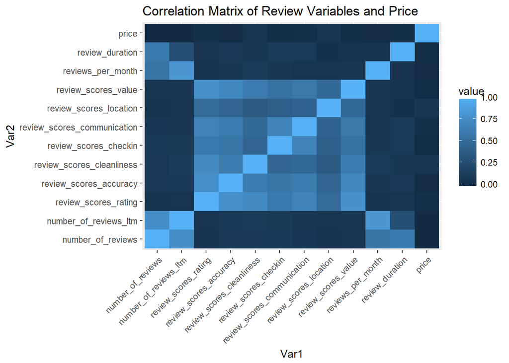

```r
ggplot(dfplot, aes(x = Var1, y = Var2, fill = value)) +
  geom_tile() +
  theme(axis.text.x = element_text(angle = 45, hjust = 1)) +
  ggtitle("Correlation Matrix of Review Variables and Price")
```

*Price is not highly correlated with any of the review variables.It probably means that hosts aren’t setting prices based on what people are saying about the rentals and pricing is more influenced by market forces/other factors.*

### Plot: How Does Neighborhood-Based Census Data Correlate with Price?

```r
keep_cols <- c(
  'population','population_density','housing_units','occupied_housing_units',
  'median_home_value','median_household_income','price'
)
dfplot <- as.data.frame(df) %>% .[, keep_cols] %>%
  .[, sapply(., is.numeric)] %>% .[complete.cases(.),]
dfplot <- melt(cor(dfplot))
```

```r
dfplot[dfplot$Var1 == 'price',] %>%
  kable(., caption = "Correlation of Census Variables to Price", row.names = FALSE)
```

Correlation of Census Variables to Price

| Var1 | Var2 | value |
| --- | --- | --- |
| price | population | -0.0927898 |
| price | population_density | 0.0447345 |
| price | housing_units | -0.0201155 |
| price | occupied_housing_units | -0.0278730 |
| price | median_home_value | 0.1340796 |
| price | median_household_income | 0.1330152 |
| price | price | 1.0000000 |

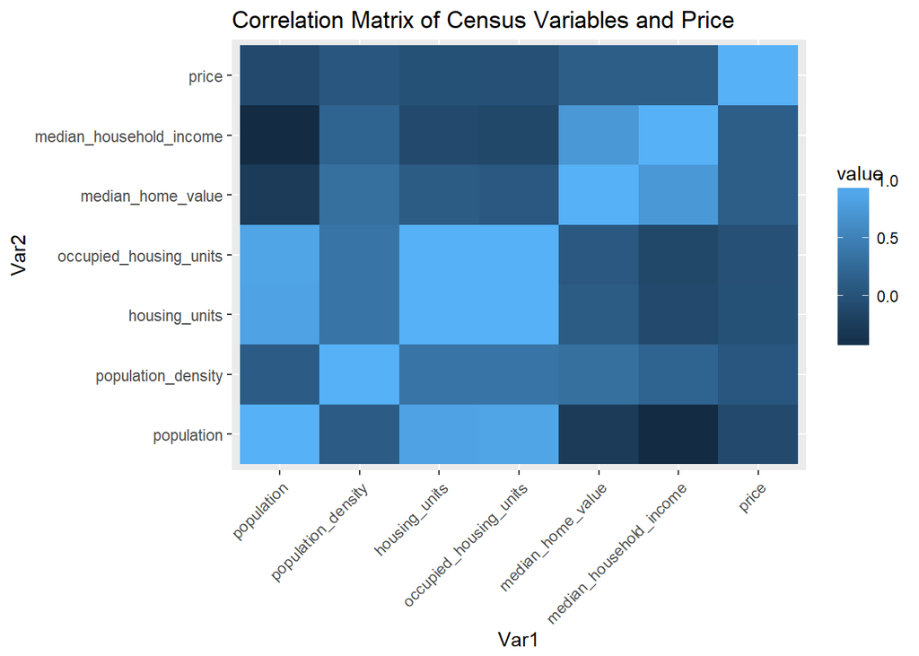

```r
ggplot(dfplot, aes(x = Var1, y = Var2, fill = value)) +
  geom_tile() +
  theme(axis.text.x = element_text(angle = 45, hjust = 1)) +
  ggtitle("Correlation Matrix of Census Variables and Price")
```

### Plot: How Does Neighbourhood Persona (PRIZM Attributes) Relate with Price?

```r
# discretize price into 5 equal frequency bins
df$priceDisc <- arules::discretize(df$price, method = 'frequency', categories = 5)
```

```r
dat <- as.data.frame(df)
# remove prizm_cluster = 'UNK' (unknown)
dat <- dat[!dat$prizm_cluster == 'UNK',]
# keep just the top prizm clusters that make up 80% of the data
clust_freq <- sort(table(dat$prizm_cluster), decreasing = TRUE)
clust_keep <- clust_freq[which(cumsum(clust_freq) <= 0.8 * sum(clust_freq))] %>% names
dat <- dat[dat$prizm_cluster %in% clust_keep,]
# normalize the prizm features for each cluster
# function to normalize vector
normPrizm <- function(x) {
  paste(
    unique(
      do.call('c', strsplit(gsub("\\[|\\]|[\"']",'',x), split = ', '))
    ), collapse = ' | '
  )
}
for (i in clust_keep) {
  dat$prizm_features_norm[dat$prizm_cluster == i] <- normPrizm(
    dat$prizm_features[dat$prizm_cluster == i]
  )
}
# contingency table of clusters and discretized price
dfPlot <- table(dat[,'prizm_cluster'], dat[,'priceDisc']) %>% as.data.frame
# reorder cluster factor levels
dfPlot$Var1 <- factor(dfPlot$Var1, levels = clust_keep)
# scale frequency relative to cluster
for (i in clust_keep) {
  dfPlot$Freq[dfPlot$Var1 == i] <- scale(dfPlot$Freq[dfPlot$Var1 == i])
}
```

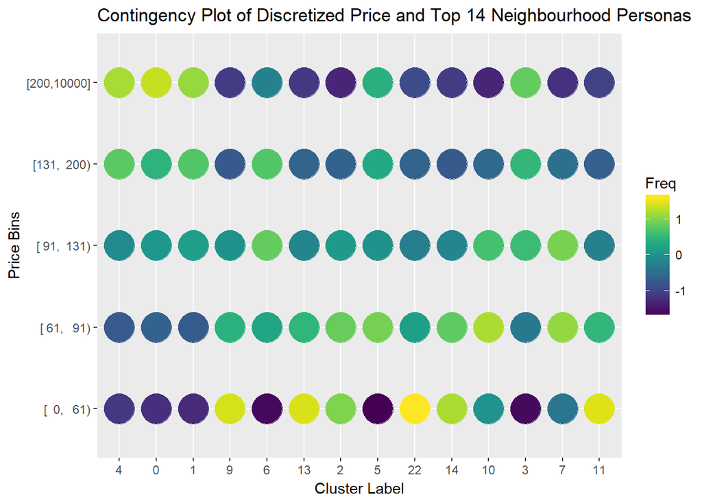

```r
ggplot(dfPlot, aes(Var1, Var2)) +
  geom_point(size = 10, aes(color = Freq)) +
  scale_color_viridis() +
  xlab("Cluster Label") + ylab("Price Bins") +
  ggtitle("Contingency Plot of Discretized Price and Top 14 Neighbourhood Personas")
```

```r
desc = sapply(clust_keep, function(x) unique(dat$prizm_features_norm[dat$prizm_cluster == x]))

dfClustDesc <- data.frame(
  cluster = clust_keep,
  description = desc
)
# table of cluster definitions
kable(dfClustDesc, row.names = FALSE)
```

| cluster | description |
| --- | --- |
| 4 | Young Digerati \| Urban Elders \| Connected Bohemians \| Money & Brains \| The Cosmopolitans |
| 0 | Connected Bohemians \| Urban Elders \| Young Digerati \| Aspiring A-Listers \| Money & Brains |
| 1 | Connected Bohemians \| Urban Elders \| Aspiring A-Listers \| Young Digerati \| The Cosmopolitans \| Money & Brains \| American Dreams \| Movers & Shakers \| Multi-Culti Families \| Urban Achievers \| … |
| 9 | Low-Rise Living \| Urban Elders \| Aspiring A-Listers \| City Roots \| Multi-Culti Mosaic |
| 6 | Connected Bohemians \| Urban Elders \| Low-Rise Living \| Young Digerati \| Aspiring A-Listers |
| 13 | Multi-Culti Mosaic \| Aspiring A-Listers \| Low-Rise Living \| Connected Bohemians \| Urban Elders |
| 2 | Aspiring A-Listers \| Urban Elders \| Connected Bohemians \| The Cosmopolitans \| Low-Rise Living |
| 5 | Connected Bohemians \| Urban Elders \| Aspiring A-Listers \| Multi-Culti Families \| Young Digerati |
| 22 | Multi-Culti Mosaic \| Low-Rise Living \| Multi-Culti Families \| Urban Modern Mix \| City Roots |
| 14 | Low-Rise Living \| Connected Bohemians \| Multi-Culti Mosaic \| Aspiring A-Listers \| Multi-Culti Families |
| 10 | Low-Rise Living \| Urban Elders \| Aspiring A-Listers \| Connected Bohemians \| Money & Brains |
| 3 | Low-Rise Living \| Urban Elders \| Connected Bohemians \| City Roots \| Money & Brains |
| 7 | Low-Rise Living \| Aspiring A-Listers \| Urban Elders \| Connected Bohemians \| City Roots |
| 11 | Low-Rise Living \| Multi-Culti Mosaic \| City Roots \| Connected Bohemians \| Aspiring A-Listers |

Takeaways:

- *Neighbourhood personas that generally price their listings lower are:*
  - Low-Rise Living | Urban Elders | Aspiring A-Listers | City Roots | Multi-Culti Mosaic | Connected Bohemians | Multi-Culti Families | Urban Modern Mix
- *Neighbourhood personas that generally price their listings higher, but to a lesser proportion include:*
  - Young Digerati | Urban Elders | Connected Bohemians | Money & Brains | The Cosmopolitans | Aspiring A-Listers

# Visualization for Other Exploratory Analysis

### How does the number of listings by host relate to price; Segmented by Neighbourhood Group

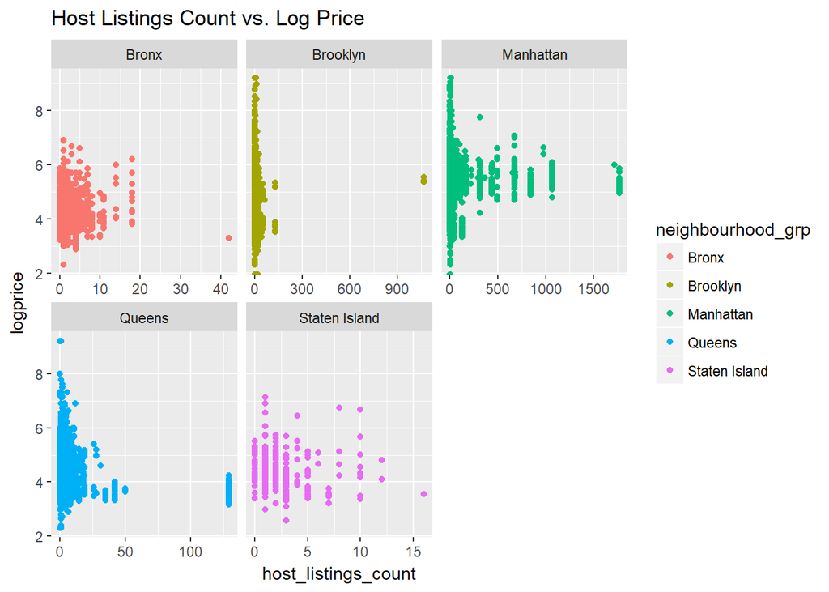

```r
df$logprice <- log(df$price)
dfplot <- df[,c('logprice','host_listings_count','neighbourhood_group_cleansed')]
colnames(dfplot) <- c('logprice','host_listings_count','neighbourhood_grp')

ggplot(dfplot, aes(x = host_listings_count, y = logprice, color = neighbourhood_grp)) +
  facet_wrap(~neighbourhood_grp, scales = 'free_x') +
  geom_point() +
  ggtitle("Host Listings Count vs. Log Price")
```

*Hosts that list many units on AirBnb generally tend to price more modestly than hosts with fewer listings to their name. This is most clearly seen in Manhattan and Queens by the funnel-shaped visualizations. It is not always the case as seen in the lower-tier neighbourhoods. Here very few hosts have many listings, the market is not as saturated and the costs of doing business are not as high.*

### Map of NYC showing prices and Census information by location

```r
# transform data for plot
# get latitude and longitude coordinates from original data
keep_cols <- c(
  'id','state','price','population','median_home_value',
  'median_household_income','neighbourhood_group_cleansed'
)
# listings_cleaned
df <- as.data.frame(df)[,keep_cols]
# original 2019 listings summary
df2 <- as.data.frame(df_list[[5]])[,c('id','latitude','longitude')]
dfplot <- merge(df, df2, by = 'id') %>% .[complete.cases(.),]
# filter on just state == 'NY'
dfplot <- dfplot[dfplot$state == 'NY',]
# change 'NY' to 'new york'
dfplot$state <- 'new york'
```

```r
# specify latitude longitude coordinate limits
xlim.min = min(dfplot$longitude)
xlim.max = max(dfplot$longitude)
ylim.min = min(dfplot$latitude)
ylim.max = max(dfplot$latitude)
```

```r
# specify state map data
us <- map_data('state')
```

### Density of Listings

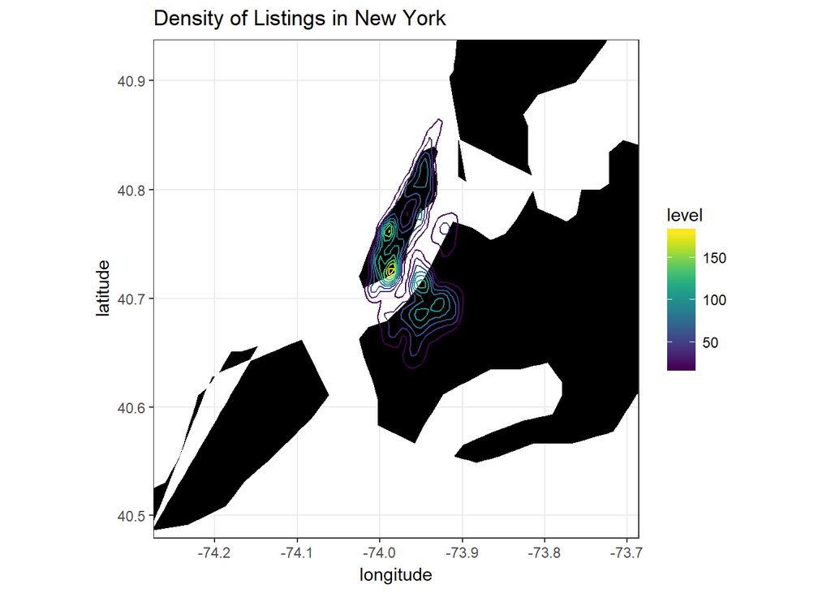

```r
# Density of listings
ggplot(dfplot, aes(map_id = state, x = longitude, y = latitude)) +
  geom_map(map = us, fill = 'black', color = 'white') +
  expand_limits(x = us$long, y = us$lat) +
  coord_map() +
  scale_color_viridis() +
  theme_bw() +
  stat_density2d(aes(color = ..level..)) +
  xlim(xlim.min, xlim.max) + ylim(ylim.min, ylim.max) +
  ggtitle("Density of Listings in New York")
```

*Most listings are densely clustered in Manhattan and Brooklyn*

### Median Household Income by zipcode

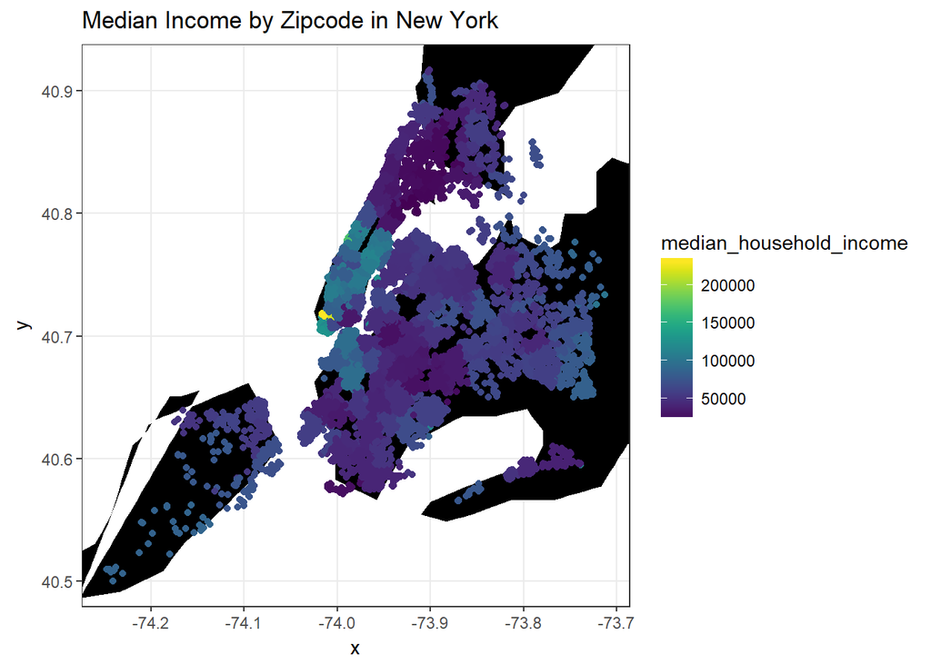

```r
# median household income by Zipcode
ggplot(dfplot, aes(map_id = state)) +
  geom_map(map = us, fill = 'black', color = 'white') +
  expand_limits(x = us$long, y = us$lat) +
  coord_map() +
  geom_point(aes(x = longitude, y = latitude, col = median_household_income)) +
  scale_color_viridis() +
  theme_bw() +
  xlim(xlim.min, xlim.max) + ylim(ylim.min, ylim.max) +
  ggtitle("Median Income by Zipcode in New York")
```

### Median Home Value by zipcode

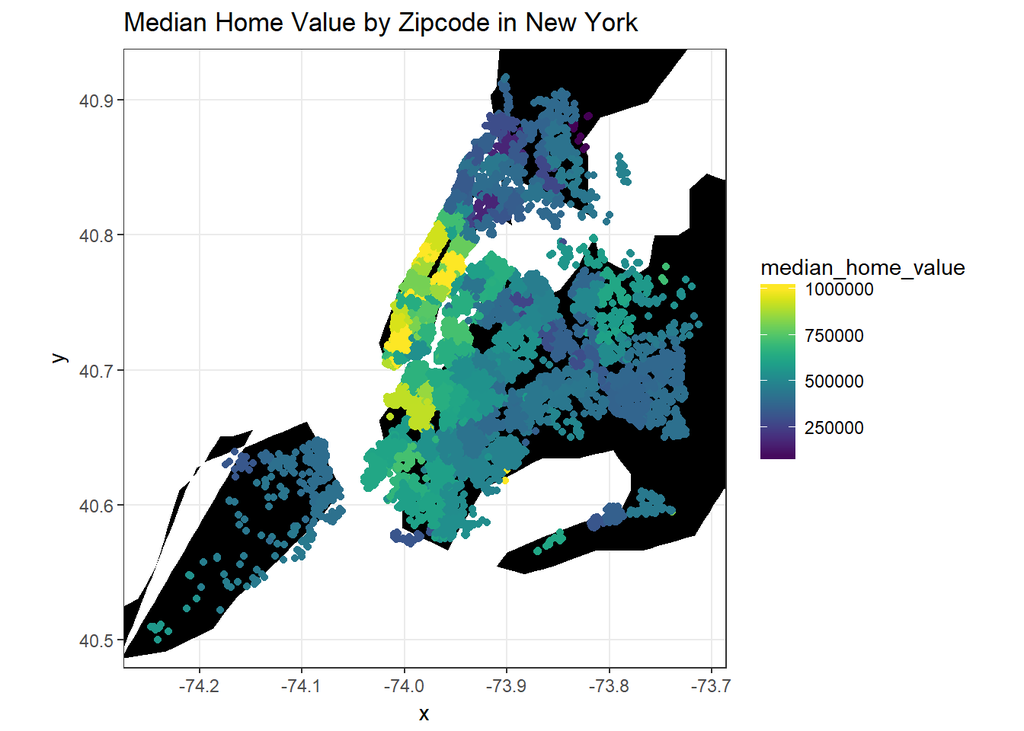

```r
# median home value income by Zipcode
ggplot(dfplot, aes(map_id = state)) +
  geom_map(map = us, fill = 'black', color = 'white') +
  expand_limits(x = us$long, y = us$lat) +
  coord_map() +
  geom_point(aes(x = longitude, y = latitude, col = median_home_value)) +
  scale_color_viridis() +
  theme_bw() +
  xlim(xlim.min, xlim.max) + ylim(ylim.min, ylim.max) +
  ggtitle("Median Home Value by Zipcode in New York")
```

### Population by zipcode

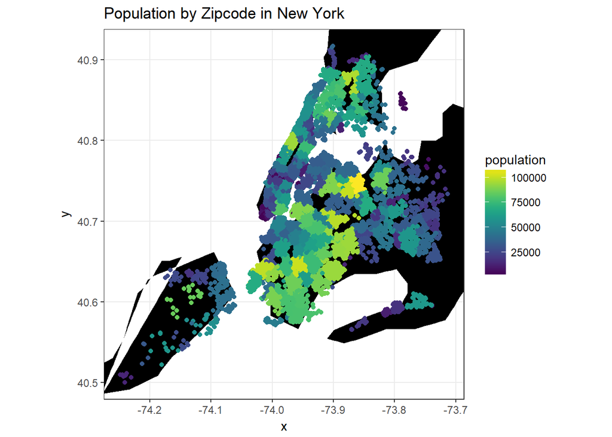

```r
# population income by Zipcode
ggplot(dfplot, aes(map_id = state)) +
  geom_map(map = us, fill = 'black', color = 'white') +
  expand_limits(x = us$long, y = us$lat) +
  coord_map() +
  geom_point(aes(x = longitude, y = latitude, col = population)) +
  scale_color_viridis() +
  theme_bw() +
  xlim(xlim.min, xlim.max) + ylim(ylim.min, ylim.max) +
  ggtitle("Population by Zipcode in New York")
```

*The plot shows that most people live in the vicinities surrounding Manhattan, particular in Queens, Brooklyn, Bronx, and Staten Island. Therefore, listings in Brooklyn and Queens are situated in zipcodes where most people reside, despite most of the listings being located in Manhattan, a place with high employment density.*

### Price by Listings New York Greater than 99th Percentile of Price

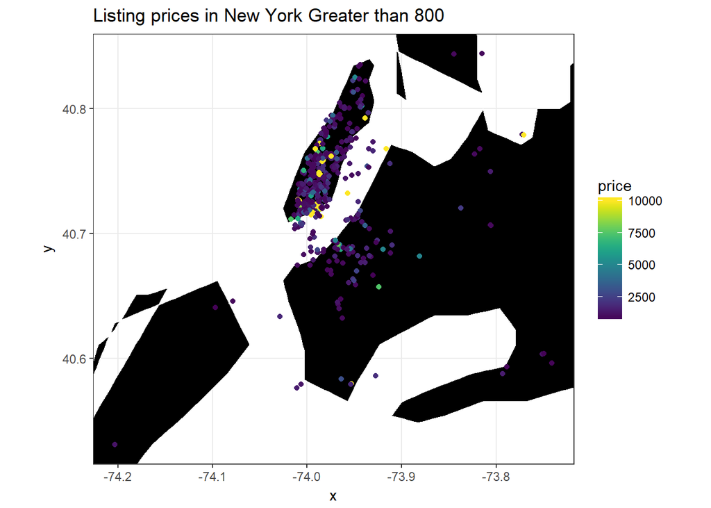

```r
# specify latitude longitude coordinate limits
lb = 800 # lower bound
criteria = dfplot$price > lb
xlim.min = min(dfplot$longitude[criteria])
xlim.max = max(dfplot$longitude[criteria])
ylim.min = min(dfplot$latitude[criteria])
ylim.max = max(dfplot$latitude[criteria])
# Listing prices in New York
ggplot(dfplot[criteria,], aes(map_id = state)) +
  geom_map(map = us, fill = 'black', color = 'white') +
  expand_limits(x = us$long, y = us$lat) +
  coord_map() +
  geom_point(aes(x = longitude, y = latitude, col = price)) +
  scale_color_viridis() +
  theme_bw() +
  xlim(xlim.min, xlim.max) + ylim(ylim.min, ylim.max) +
  ggtitle(paste("Listing prices in New York Greater than", lb))
```

*Most of the very high priced listings (i.e. greater than 99th percentile) are in Manhattan and possibly north Brooklyn. The vast majority of listings are priced under 200.*